# exercise5

Johnny Chiu

2017/9/11

# Setup

```r
library(tidyverse)
```

```r
library(gapminder)
library(dplyr)
library(ggplot2)
gapminder<-read_csv("https://goo.gl/dWrc9m")
schooldata <- read_csv("~/team/bootcamp/R/schooldata.csv")
```

# Exercise: Make a Line Plot

Using the gapminder data, make a line plot showing the population of Afghanistan over time. Do this first with base R plotting and then with ggplot. Hint: for base R, look at the help for plot.default and the type parameter. For ggplot, use the cheat sheet to find the correct geom to use.

Make sure to clean up the x and y labels, and give your plot a title.

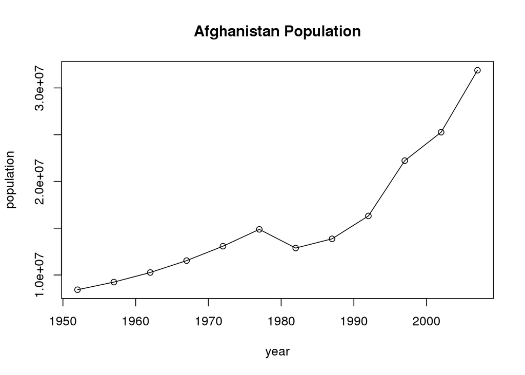

```r
# base R
data_afghanistan <- gapminder %>% filter(country=='Afghanistan')
plot(data_afghanistan$year, data_afghanistan$pop, xlab='year', ylab='population', main='Afghanistan Population')
lines(data_afghanistan$year, data_afghanistan$pop)
```

```r
dev.off()
```

```r
# ggplot
ggplot(data=data_afghanistan,aes(x=year, y=pop),title=) +
  geom_line() +
  geom_point() +
  ggtitle('Afghanistan Population', subtitle = NULL)
```

[output not shown]

# Exercise: Histogram

Make a histogram of life expectancies in 2007. Make the historgram with each of 5, 10, 20, and 40 bins. Use either base R or ggplot functions (or do both). Does the number of bins change your interpretation of the data at all? Do you see different trends?

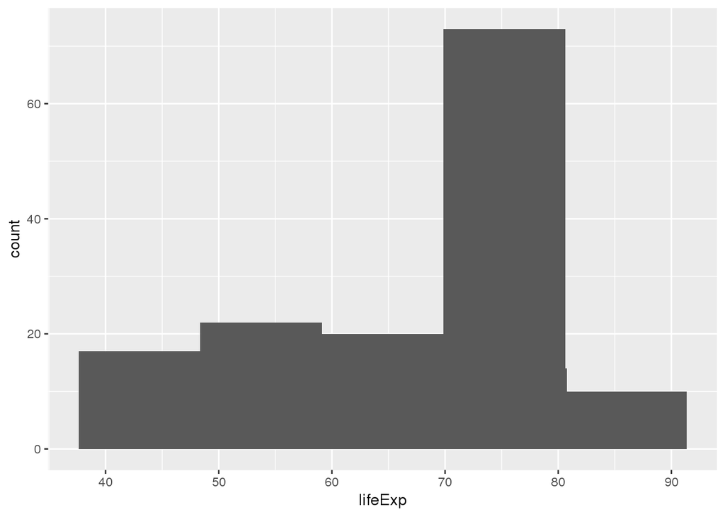

```r
data_2007 <- gapminder %>% filter(year==2007)
ggplot(data=data_2007, aes(lifeExp)) +
  geom_histogram() +
  stat_bin(bins=5)
```

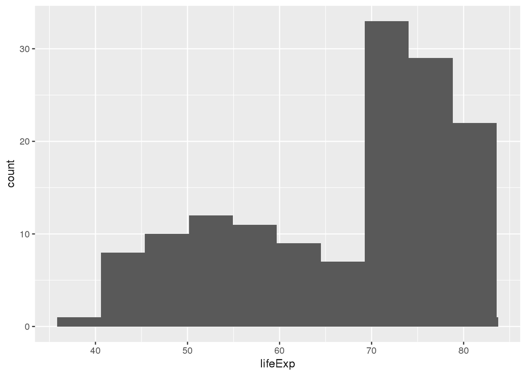

```r
ggplot(data=data_2007, aes(lifeExp)) +
  geom_histogram() +
  stat_bin(bins=10)
```

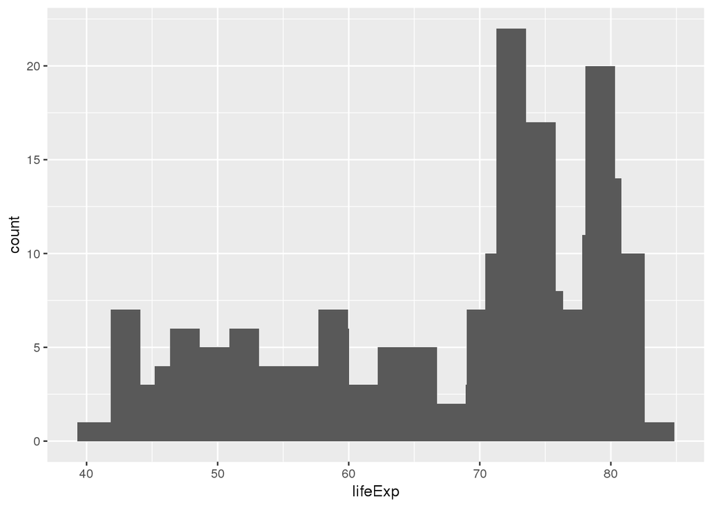

```r
ggplot(data=data_2007, aes(lifeExp)) +
  geom_histogram() +
  stat_bin(bins=20)
```

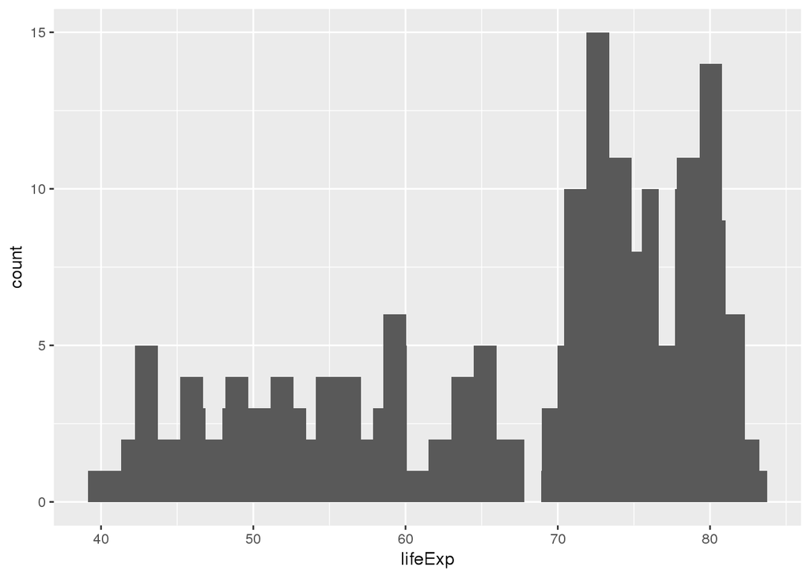

```r
ggplot(data=data_2007, aes(lifeExp)) +
  geom_histogram() +
  stat_bin(bins=40)
```

# ggplot Exercise: Change Colors

Using the gapminder data, repeat the plot we made together of life expectancy vs. GDP per capita, with points colored by continent. Instead of using the default colors, use the palette below. Hint: use scale_colour_manual to set the colors.

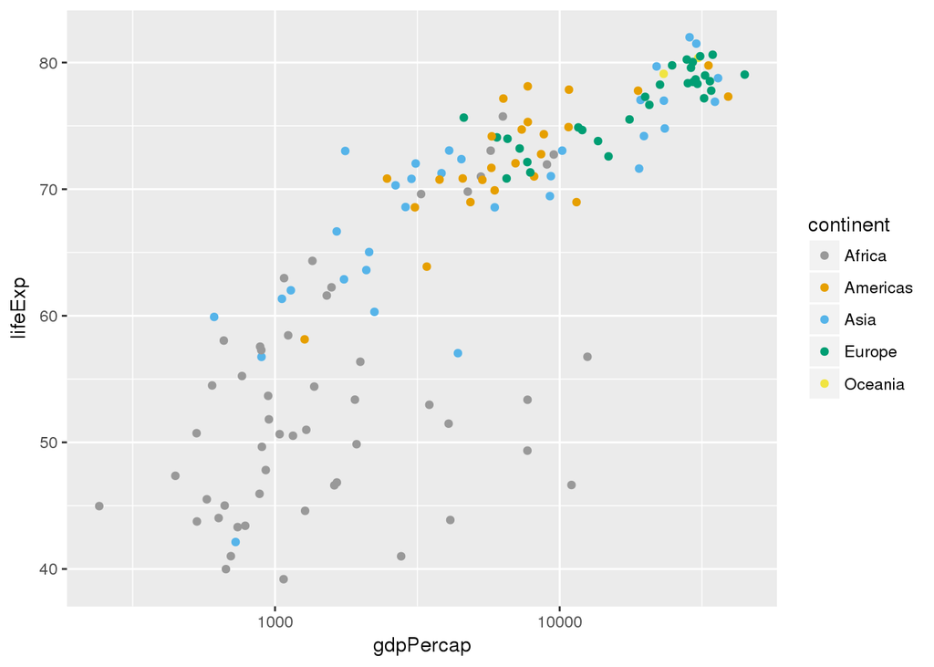

```r
cbPalette <- c("#999999", "#E69F00", "#56B4E9", "#009E73",
               "#F0E442", "#0072B2", "#D55E00", "#CC79A7")
filter(gapminder, year==2002) %>%
  ggplot(aes(x=gdpPercap, y=lifeExp, color=continent)) +
  geom_point() +
  scale_colour_manual(values=cbPalette) +
  scale_x_log10()
```

# ggplot Exercise: Multiple lines and facets

Using the gapminder data, create a plot to show the change in life expectancy over time. Plot one line for each country. Color the lines by continent. Include decent labels on your plot. Hint: you will set 4 aesthetics: x, y, by, and color.

Then add the points for each observation to the plot as well (so that you have a line with points on it). Hint: you can use multiple geoms in the same plot.

Then split out the countries by continent, so there is one plot per continent. Challenge: Remove the legend on this final plot, as it is redundant with the plot labeling. Hint: look at legend.position argument to the theme function.

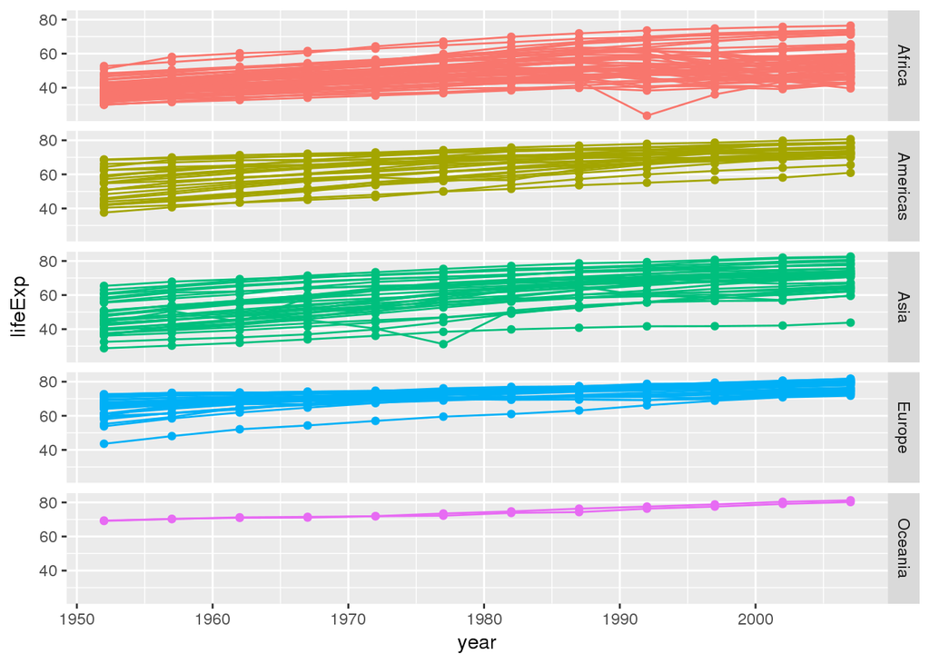

```r
ggplot(data=gapminder, aes(x=year,y=lifeExp,by=country,color=continent)) +
  geom_line() +
  geom_point() +
  facet_grid(continent~.) +
  theme(legend.position="none")
```

# ggplot Exercise: Add a Trend Line

Create a scatter plot of life expectancy vs. log of population for the year 2007. Color points by continent. Add a linear regression line for each continent. Hint: use geom_smooth and set method=lm for linear regression.

Then redo the plot with a single overall trend line (don’t worry about coloring points by continent anymore). What do you notice?

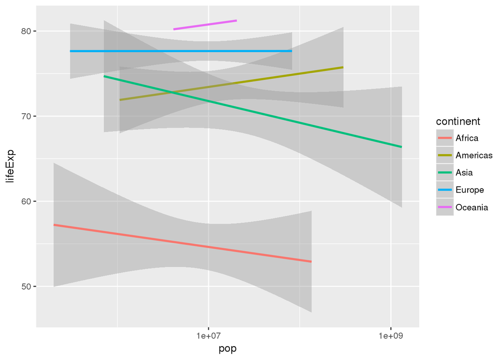

```r
gapminder %>%
  filter(year==2007) %>%
  ggplot(aes(x=pop, y=lifeExp, color=continent)) +
  geom_smooth(method=lm) +
  scale_x_log10()
```

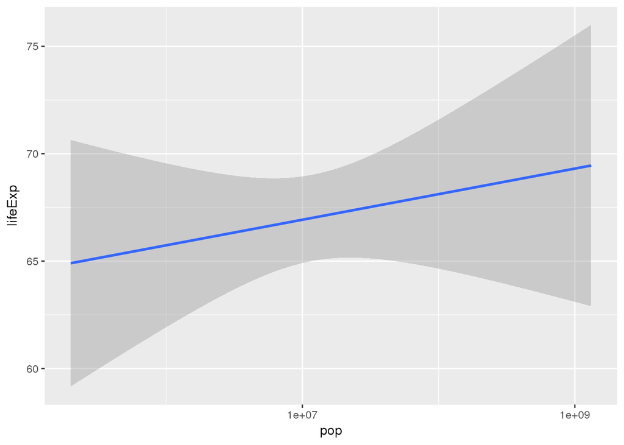

```r
gapminder %>%
  filter(year==2007) %>%
  ggplot(aes(x=pop, y=lifeExp)) +
  geom_smooth(method=lm) +
  scale_x_log10()
```

In year 2007, for Asia and Africa, the more the pop is, the less lifeExp there will be.